# Problem Set 4

Bruk Esayas

11/20/2026

**GitHub repo:** https://github.com/00bruk/ec522_ps4_esayas

## ARIMA vs. ETS

### 2.1 The Data

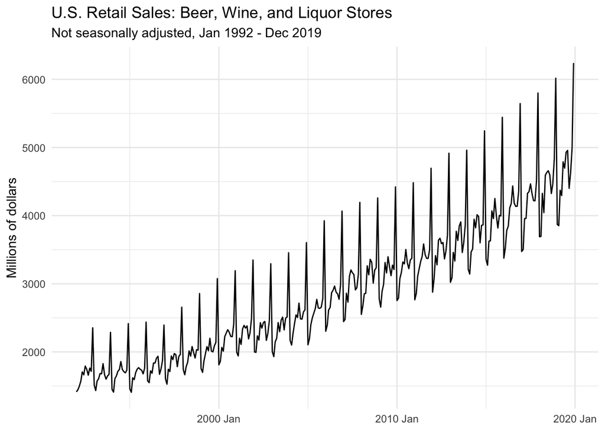

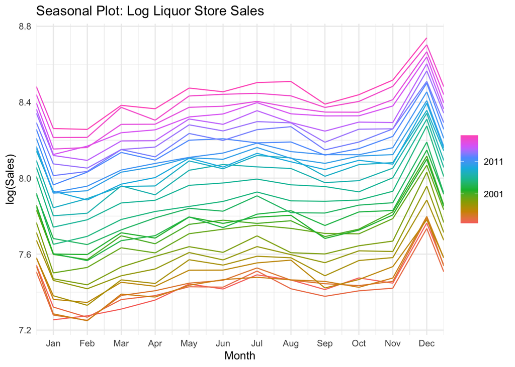

Sales are trending up from 1992-2019. The holidays show a peak each year (December) with January to February being the lowest. The seasonal swing is growing with the level of sales but displays stability when logged, so I would apply log of sales.

### 2.2 Fit Both Models

```
## Series: sales
## Model: ARIMA(1,0,2)(2,1,1)[12] w/ drift
## Transformation: log(sales)
##
## Coefficients:
##          ar1      ma1     ma2    sar1     sar2     sma1  constant
##       0.8948  -0.7374  0.2477  0.3679  -0.2334  -0.8845    0.0036
## s.e.  0.0355   0.0697  0.0623  0.0668   0.0665   0.0468    0.0001
##
## sigma^2 estimated as 0.0005469:  log likelihood=752.43
## AIC=-1488.85   AICc=-1488.4   BIC=-1458.61
```

```
## Series: sales
## Model: ETS(A,A,A)
## Transformation: log(sales)
##   Smoothing parameters:
##     alpha = 0.3296099
##     beta  = 0.007560263
##     gamma = 0.0001765132
##
##   Initial states:
##      l[0]         b[0]      s[0]      s[-1]        s[-2]       s[-3]      s[-4]
##  7.412219 0.0007608238 0.3263441 0.03153301 -0.004849389 -0.03530501 0.02512163
##       s[-5]      s[-6]      s[-7]       s[-8]      s[-9]     s[-10]     s[-11]
##  0.05558624 0.01219515 0.02503206 -0.06088935 -0.0607952 -0.1578065 -0.1561667
##
##   sigma^2:  7e-04
##
##       AIC      AICc       BIC
## -489.1517 -487.2272 -424.2608
```

ARIMA chose ARIMA(1,0,2)(2,1,1)[12] w/ drift. Series was not differenced (d = 0) but seasonally differenced one time (D = 1), so each month is compared to the same month from a year earlier. ETS chose ETS(A,A,A): additive errors, additive trend, and additive seasonality. Since the model is on log of sales, additive seasonality implies that the seasonalswings are a constant % of the level.

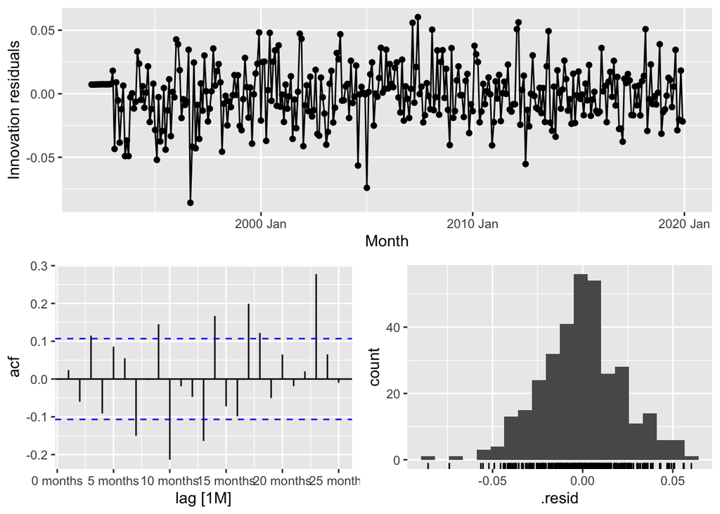

| .model | lb_stat | lb_pvalue |
| --- | --- | --- |
| arima | 120.39 | 0 |

Residuals centered at 0 and normal, but a few ACF spikes (ie. lag 24) are outside the bounds. Ljung-Box test rejects white noise (p<0.05), so some of the seasonal features are left over. The horse race will show us whether or not that hurts our forecast.

### 2.3 The Horse Race

| .model | .type | RMSE | MAE |
| --- | --- | --- | --- |
| arima | Test | 81.43 | 65.65 |
| ets | Test | 94.35 | 72.31 |
| snaive | Test | 161.26 | 136.63 |

216 forecast origins (336 months minus the 120-month first training sample, minus the last one with no actual value). First forecast: Jan 2002. Last: Dec 2019. ARIMA is most accurate (RMSE 81.4, MAE 65.7), then ETS, then the seasonal random walk. Both metrics agree.

### 2.4 DM Tests

ARIMA vs. ETS: DM = -2.91, p = 0.004. ARIMA vs. SNAIVE: DM = -10.76, p < 0.001. ARIMA is significantly more accurate than both, so I’d use ARIMA for the liquor chain.

## Forecast Combination

| .model | .type | RMSE | MAE |
| --- | --- | --- | --- |
| arima | Test | 81.43 | 65.65 |
| combo | Test | 85.19 | 66.77 |
| ets | Test | 94.35 | 72.31 |
| snaive | Test | 161.26 | 136.63 |

The combo (RMSE 85.2) beats ETS but not ARIMA. It lands between the two.

The correlation between ARIMA and ETS errors is 0.88, so the two models mostly make the same mistakes and there’s little to average out. Since ARIMA is also significantly better (DM test), giving ETS half the weight drags the combo down.

## VAR vs. BVAR

### 4.1 Data

120 forecasts pervariable (240 quarters minus the 120-quarter training sample). First forecast is 1990 Q1 and the last 2019 Q4.

### 4.2 OLS VARs

VAR1 beats VAR4 for 7/8 variables (all except for inflation which nearly tied). VAR4 has 264 coefficients vs 72 for VAR1. It is overfitting noise from the training sample which adds some estimation error to its forecasts.

### 4.3 BVAR

| Variable | VAR(1) | VAR(4) | BVAR(4), lambda = 0.3 | BVAR(4), lambda = 0.05 |
| --- | --- | --- | --- | --- |
| gdp | 0.513 | 0.569 | 0.539 | 0.567 |
| cons | 0.460 | 0.527 | 0.486 | 0.495 |
| inv | 2.493 | 2.521 | 2.385 | 2.698 |
| emp | 0.196 | 0.228 | 0.211 | 0.315 |
| infl | 0.208 | 0.207 | 0.197 | 0.330 |
| unrate | 0.199 | 0.215 | 0.203 | 0.216 |
| ffr | 0.390 | 0.497 | 0.414 | 0.358 |
| gs10 | 0.361 | 0.379 | 0.359 | 0.362 |

```
##
##  Diebold-Mariano Test
##
## data:  e_var4e_bvar
## DM = 2.1366, Forecast horizon = 1, Loss function power = 2, p-value =
## 0.03468
## alternative hypothesis: two.sided
```

```
##
##  Diebold-Mariano Test
##
## data:  e_var4_inve_bvar_inv
## DM = 1.6265, Forecast horizon = 1, Loss function power = 2, p-value =
## 0.1065
## alternative hypothesis: two.sided
```

BVAR4 with lambda = 0.3 beats the OLS VAR4 for all of the variables. Same variables and lags so the gain comes solely from the Minnesota prior decreasing the 264 coefficients towards zero (cuts estimation error).

Against the VAR1, the BVAR wins for 3 of the variables (investment, inflation and 10-year yield) and loses for the 5.

w/ lambda = 0.05, RMSEs get worse for most variables (employment and inflation by a relatively great amount) and only improve for the fed. funds rate. That’s way too much shrinkage (the coefficients are pushed so close to zero that the model loses real function). The winners RMSE in this table would not be a fair estimate of future accuracy since we picked it once we saw the results on this same sample.

DM tests (VAR4 vs. BVAR lambda = 0.3): GDP growth DM = 2.14, p = 0.035, so the BVAR is more accurate. Investment growth w/ DM = 1.63, p = 0.107 (not significant). So some of the RMSE gaps in the table could be noise.

## Factor Model

### 5.1–5.2 Data and Factors

```
##   INDPRO   PAYEMS CPIAUCSL FEDFUNDS
##        5        5        6        2
```

```
##                             PC1      PC2      PC3      PC4      PC5
## Standard deviation     4.258002 2.993839 2.923106 2.597224 2.295261
## Proportion of Variance 0.149840 0.074070 0.070620 0.055750 0.043540
## Cumulative Proportion  0.149840 0.223910 0.294530 0.350280 0.393820
```

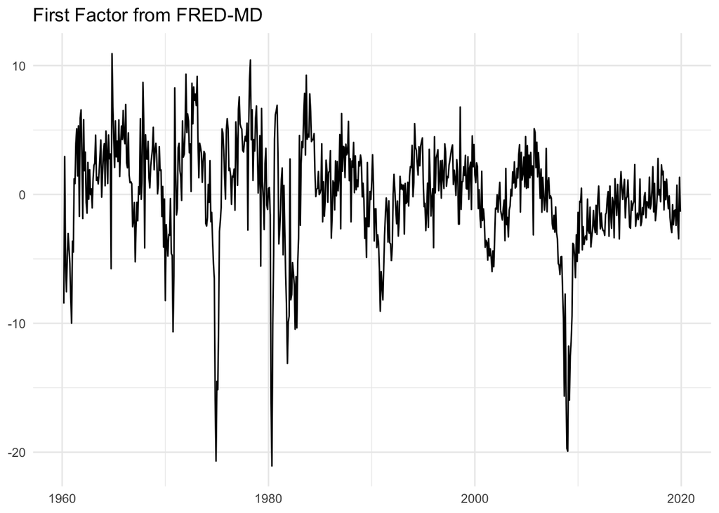

```
##    PAYEMS IPMANSICS    USGOOD    INDPRO    MANEMP   IPFPNSS    CUMFNS   DMANEMP
## 0.8415788 0.8404473 0.8390159 0.8219976 0.8028499 0.7903078 0.7778686 0.7768615
```

```
##     CUSR0000SAC DNDGRG3M086SBEA   CUSR0000SA0L2        CPIAUCSL   CUSR0000SA0L5
##       0.7468587       0.7391330       0.7279202       0.7198020       0.7020307
##        CPITRNSL           PCEPI        CPIULFSL
##       0.6806883       0.6795890       0.6570361
```

INDPRO (code 5): monthly growth rate. PAYEMS (code 5): monthly growth rate. CPIAUCSL (code 6): change in the monthly inflation rate. FEDFUNDS (code 2): first differenced. Int rates are already in % and can be near zero, so logs don’t make sense; a simple difference makes them stationary.

The first 3 factors explain 29.5% of the variation in the 121 series (15.0%, 7.4%, 7.1%).

Factor 1 has most correlation w/ payroll employment, industrial production, and manufacturing hours/employment, so it’s a real activity factor; it drops sharply in recessions (1974–75, 1980–82, 2008–09). Factor 2 is most correlated w/ CPI and PCE, so it’s an nflation factor.

### 5.3 IP Horse Race

```
##   RMSE_AR   RMSE_FA
## 0.6168431 0.5887272
```

RMSEs 0.617 for the AR1 and 0.589 w/ factors. Estimating the factors once on the full sample would be dishonest because each forecast would use data from after the forecast origin (biased), making the factor model look better than it could be in real time.

### 5.4 Direct Forecast of Inflation

| series | forecasts | RMSE_AR | RMSE_FA | MAE_AR | MAE_FA | DM_pvalue |
| --- | --- | --- | --- | --- | --- | --- |
| CPIAUCSL | 349 | 2.108 | 1.894 | 1.578 | 1.349 | 0 |

Yes, addding in factors cuts the RMSE of 12 month CPI inflation forecasts (from 2.11 to 1.89, about a 10.2% reduction). MAE drops from 1.58 to 1.35. The DM p-value is 0.0004 which means the improvement is statistically significant.

## Reflection

Simple models were hard to beat when complex ones had too many things to estimate. VAR1 beat VAR4, and ARIMA’s leftover residual correlation didn’t stop it from winning. The thing that kept coming up was lowering the estimation error. Shrinkage pushes coefficients toward zero while equal weights skip estimating combination weights and factors squeeze 121 different series into 3. Each has a tradeoff of a bit of bias for less variance.I t can be pushed too far, (like w/ lambda = 0.05).

DM tests also showed that many RMSE differences aren’t significant which implies small gaps shouldn’t drive model choice.